# Gardner-TwoStageDiD-2021-arXiv.pdf

Page 1

## Two-stage differences in differences

#### John Gardner<sup>∗</sup>

#### This version: April 2021

#### **Abstract**

A recent literature has shown that when adoption of a treatment is staggered and

average treatment effects vary across groups and over time, difference-in-differences

regression does not identify an easily interpretable measure of the typical effect of

the treatment. In this paper, I extend this literature in two ways. First, I provide

some simple underlying intuition for why difference-in-differences regression does not

identify a group*×*period average treatment effect. Second, I propose an alternative two-

stage estimation framework, motivated by this intuition. In this framework, group and

period effects are identified in a first stage from the sample of untreated observations,

and average treatment effects are identified in a second stage by comparing treated

and untreated outcomes, after removing these group and period effects. The two-stage

approach is robust to treatment-effect heterogeneity under staggered adoption, and

can be used to identify a host of different average treatment effect measures. It is

also simple, intuitive, and easy to implement. I establish the theoretical properties

of the two-stage approach and demonstrate its effectiveness and applicability using

Monte-Carlo evidence and an example from the literature.

**Keywords:** Differences in differences, treatment effects, program evaluation, het-

erogenous treatment effects, misspecification.

**JEL codes:** C01, C10, C21, C22, C23.

∗Department of Economics, University of Mississippi, University, MS. jrgardne@olemiss.edu. I thank Kyle Butts, Tao Wang, and participants at the Western Economics Association International conference for helpful comments and suggestions.

### arXiv:2207.05943v1 [econ.EM] 13 Jul 2022

Page 2

### **1 Introduction**

The difference-in-differences methodology has become an essential part of the applied em-

piricist’s toolkit for evaluating treatment effects. Recently, however, an insightful literature

has shown that, when the adoption of the treatment by different groups is staggered over

time, and the average effects of the treatment vary over groups and across time, the usual

difference-in-differences regression specification does not identify a readily interpretable mea-

sure of the typical effect of the treatment (see Borusyak and Jaravel, 2017; Athey and Im-

bens, 2018; Goodman-Bacon, 2018; de Chaisemartin and D’Haultfœuille, 2020; Imai and

Kim, 2020; Sun and Abraham, 2020). Given the popularity, and the utility, of differences in

differences, this is disconcerting.

In this paper, I extend the literature on difference-in-differences with staggered adoption

and heterogeneous treatment effects in two ways. First, I present some clarifying intuition

for why differences-in-differences may not identify the average effect of the treatment on

the treated. Motivated by this intuition, I then develop a simple two-stage alternative

to difference-in-differences regression that is robust to treatment-effect heterogeneity when

adoption is staggered.

Presumably, part of why difference-in-differences regression is ubiquitous in settings with

multiple groups and time periods is because it seems natural that it should identify the

average effect of the treatment on the treated.<sup>1</sup> Since it *does* identify the average of hetero-

geneous treatment effects as long as those effects are distributed identically across treatment

groups and periods (a condition that holds automatically in the classical two-group, two-

period setting), this is an understandable misconception. When those distributions are not

identical, however, conditional mean outcomes are not linear in group, period, and treat-

ment status, so the standard differences-in-differences regression model is misspecified, and

therefore does not identify the average effect of the treatment on the treated.

1As Borusyak and Jaravel (2017) write, “...there is a perception that [differences in differences] should estimate average treatment effects with some reasonable weights.”

1

Page 3

The helps explain why differences-in-differences may not identify the average effect of

the treatment on the treated, but says little about what it does identify. Several pa-

pers have provided alternative representations of the difference-in-difference regression esti-

mand. Borusyak and Jaravel (2017) show that regression difference-in-differences identifies

a regression-weighted mean of the average effect of the treatment in each post-treatment

period, and de Chaisemartin and D’Haultfœuille (2020) show that all two-way fixed-effects

regression estimates (which include difference-in-differences regressions as a special case)

identify weighted averages of group- and period-specific average treatment effects. Since the

weights in both of these representations can be negative, the difference-in-differences esti-

mand may be difficult to interpret. Goodman-Bacon (2018) further shows that the regression

difference-in-differences estimate represents a weighted average of all two-group, two-period

differences in differences, which under parallel trends identifies a combination of weighted

averages of group*×*period-specific average treatment effects and changes over time in those

effects. As I discuss below, these decomposition results can be interpreted as describing

how misspecified difference-in-differences regression models project heterogeneous treatment

effects onto group and period fixed effects, rather than treatment status itself.

There are several alternatives to the difference-in-differences regression approach that are

robust to heterogeneity across groups and periods when treatment adoption is staggered. Fol-

lowing Gibbons et al. (2017), Borusyak and Jaravel (2017), Callaway and Sant’Anna (2020),

and Sun and Abraham (2020), one alternative is to estimate separate average treatment

effects for each group and period, which can then be aggregated to form measures of the

overall effect of the treatment (Gibbons et al., 2017, suggest an approach like this for fixed ef-

fects models, Borusyak and Jaravel, 2017, suggest such a solution for difference-in-differences

models in which the duration-specific effects of the treatment are identical across groups, as

do Callaway and Sant’Anna, 2020, for the case when treatment effects vary by group and du-

ration, and Sun and Abraham, 2020, in the event-study context).<sup>2</sup> Another is the “stacked”

2One advantage of these approaches is that they enable researchers to estimate a variety of different summary measures of treatment effects. The method developed by Callaway and Sant’Anna (2020, cf. Abadie,

2

Page 4

difference-in-differences approach (see, e.g., Gormley and Matsa, 2011; Deshpande and Li,

2019; Cengiz et al., 2019), which attempts to transform the staggered adoption setting to a

two-group, two-period design (in which difference in differences identifies the overall average

effect of the treatment on the treated) by stacking separate datasets containing observations

on treated and control units for each treatment group.<sup>3</sup>

I develop an alternative, two-stage regression approach to identification that is robust to

treatment-effect heterogeneity when adoption of the treatment is staggered. In its simplest

form, the first stage of the procedure consists of a regression of outcomes on group and

period fixed effects, estimated using the subsample of untreated observations. In the second

stage, the estimated group and period effects are subtracted from observed outcomes, and

these adjusted outcomes are regressed on treatment status. Under the usual parallel trends

assumption, this procedure identifies the overall average effect of the treatment on the treated

(i.e., across groups and periods), even when average treatment effects are heterogeneous over

groups and periods.

The two-stage approach can be adapted to recover a variety of treatment effect measures,

and extended to event-study analyses of pre-trends and duration-specific average treatment

effects. In the event-study context, this same approach has also been suggested by Thakral

and Tˆo (2020) in their study of the how the anticipation of future consumption influences

spending decisions. The two-stage estimators can be implemented easily, along with valid

asymptotic standard errors, using standard statistical software, and with little programming

beyond that required to estimate a regression. It is also simple, and preserves the intuition

behind identification in the two-group, two-period case: it recovers the average difference in

outcomes between treated and untreated units, after removing group and period effects.

I motivate the problem with the difference-in-differences regression approach, and discuss

2005) also accommodates covariates (which I mostly abstract away from) more flexibly than traditional regression-based methods.

3In Appendix A, I show that this estimator identifies an average of group-specific average treatment effects, weighted by the relative sizes of the group-specific datasets and the variance of treatment status within those datasets.

3

Page 5

the difference-in-differences regression estimand, in Section 2. I introduce the two-stage

approach and its properties in Section 3. I illustrate the performance of the two-stage

approach using Monte Carlo evidence in Section 4 and its application in Section 5. I conclude

in Section 6.

### **2 Motivation**

#### **2.1 The problem with difference-in-differences regression**

Difference-in-differences research designs attempt to identify the causal effects of treatments

under the parallel or common trends assumption, which asserts that, absent the treatment,

treated units would experience the same change in outcomes as untreated units. Mathemati-

cally, this amounts to the assumption that average untreated potential outcomes decompose

into additive group and period effects. More formally, let *i* index units (e.g., states or, with

microdata, individuals) and *t* index calendar time (often years). Further divide individuals

and time into treatment groups *g ∈{*0*,* 1*, . . . , G}* and periods *p ∈{*0*,* 1*, . . . , P}* defined by

**equation / math rendering (image)**

NOTE: contains mathematical notation; text above is the PDF text layer and symbols may be mis-extracted. Image shows the original.

the adoption of the treatment among successive groups, so that members of group 0 are un-

treated in all periods, only members of group 1 are treated in period 1, members of groups

1 and 2 are treated in period 2, and so on. Let *Ygpit*, *Y*1*gpit* and *Y*0*gpit* denote the observed,

treated, and untreated potential outcomes for the *i*th member of group *g* during time *t* of

period *p*, *Dgp* be an indicator for whether members of group *g* are treated in period *p*, and

*βgp* = *E*(*Y*1*gpit −Y*0*gpit|g, p*) denote the average causal effect of the treatment for members of

*g* in *p*. Under parallel trends, mean outcomes satisfy

*E*(*Ygpit|g, p, Dgp*) = *λg* + *γp* + *βgpDgp.* (1)

**equation / math rendering (image)**

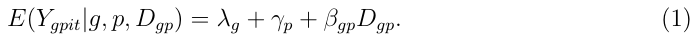

NOTE: contains mathematical notation; text above is the PDF text layer and symbols may be mis-extracted. Image shows the original.

The idea behind differences in differences is to eliminate the permanent group effects

*λg* and secular period effects *γp* in order to identify the average effect of the treatment. In

4

Page 6

the classic setup, there are only two periods (pre and post) and two groups (treatment and

control). In this setting, within-group differences over time eliminate the group effects and

within-period differences between groups eliminate the period effects. Hence the between-

group difference in post-pre differences (i.e., the difference in differences) identifies the aver-

age effect of the treatment for members of the treatment group during the post-treatment

period.

The two-period, two-group difference-in-differences estimate can be obtained manually,

by calculating each of the four group*×*period averages and taking differences, or via a re-

gression of outcomes on group and period fixed effects and a treatment-status indicator:

*Ygpit* = *λg* + *γp* + *βDgp* + *εgpit.* (2)

**equation / math rendering (image)**

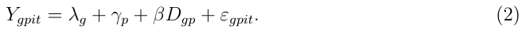

NOTE: contains mathematical notation; text above is the PDF text layer and symbols may be mis-extracted. Image shows the original.

It follows from (1) that the coefficient on *Dgp* in (2) identifies the average effect of the

treatment on the treated, or *β*11 = *E*(*Y*1*gpit −Y*0*gpit|Dgp* = 1).<sup>4</sup>

**equation / math rendering (image)**

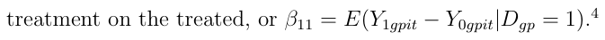

NOTE: contains mathematical notation; text above is the PDF text layer and symbols may be mis-extracted. Image shows the original.

The regression approach suggests a natural way to extend the differences-in-differences

idea to settings with multiple groups and time periods. Unfortunately, as several authors

have noted (Borusyak and Jaravel, 2017; Goodman-Bacon, 2018; Athey and Imbens, 2018;

de Chaisemartin and D’Haultfœuille, 2020; Imai and Kim, 2020), when the average effect

of the treatment varies across groups and over periods, the coefficient on *Dgp* in specifica-

tion (2) does not always identify an easily interpretable measure of the “typical” effect of

the treatment. Although this result is now well established, because it is also somewhat

counterintuitive, it bears further clarification.

While there are multiple ways to think about the typical effect of the treatment when

4There are several equivalent variations on this regression. Specification (2) is identical to a regression of outcomes on an indicator *Postit* for whether *t* occurs in the post-treatment period, an indicator *Treatit* for whether *i* belongs to the treatment group, and an interaction between the two. Often, the group and period effects *λg* and *γp* in (2) are replaced with individual and time effects *λi* and *γt*. By the Frisch-Waugh-Lovell theorem, the coefficient on *Dgp* in (2) can be obtained by regressing *Ygpit* on the residuals from a regression of treatment status on group and period effects. Since treatment status only varies by group and period, these residuals are the same as those from a regression of treatment status on individual and time effects, so the coefficients on treatment status from both specifications are identical (despite the fact that the latter model is misspecified for *E*(*Yit|i, t, Dit*)).

5

Page 7

that effect varies across groups and over time (see Section 3.1 below), an obvious candidate is

the average *E*(*βgp|Dgp* = 1) = *E*(*Y*1*gpit−Y*0*gpit|Dgp* = 1) of group- and period-specific average

treatment effects, taken over all units that receive the treatment and all times during which

they receive it. This is what differences in differences identifies in the two period, two group

case, and is probably what most people have in mind when they think about heterogenous

treatment effects averaged over groups and time. Using this measure, parallel trends can be

expressed as

*E*(*Ygpit|g, p, Dgp*) = *λg* + *γp* + *E*(*βgp|Dgp* = 1)*Dgp* + [*βgp −E*(*βgp|Dgp* = 1)]*Dgp.*

**equation / math rendering (image)**

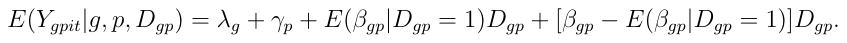

NOTE: contains mathematical notation; text above is the PDF text layer and symbols may be mis-extracted. Image shows the original.

The difficulty with the regression approach arises because, except in special cases, the “error

term” [*βgp−E*(*βgp|Dgp* = 1)]*Dgp* in this expression varies at the group*×*period level, and is not

mean zero conditional on group membership, period, and treatment status. Consequently,

the conditional expectation *E*(*Ygpit|g, p, Dgp*) is not, in general, a linear function of those

variables (at least, not one in which the coefficient on *Dgp* is *E*(*βgp|Dgp* = 1)), and (2) is

misspecified.<sup>5</sup> In contrast to the two-group, two-period case, the coefficient on *Dgp* from the

regression differences-in-differences specification (2) does not identify the average difference

*E*(*βgp|Dgp* = 1) in outcomes between treated and untreated units after removing group and

period fixed effects, unless those average effects are independent of group and period (in

which case *βgp* = *E*(*βgp|Dgp* = 1) = *β*, which the coefficient on *Dgp* recovers). Outside of

this special case, when average treatment effects vary across groups and periods, and the

adoption of the treatment by different groups is staggered over time, difference-in-differences

regression does not recover a simple group*×*period average treatment effect.

5Cf. Angrist and Pischke (2009, Theorem 3.1.4): “Suppose the CEF is linear. Then the population regression function is it.”

6

Page 8

#### **2.2 The difference-in-differences regression estimand**

The preceding argument clarifies why difference-in-differences regression may not recover

a readily interpretable measure of the average effect of the treatment, but says nothing

about what it does identify. An easy answer to that question is that (2) identifies the linear

projection of average outcomes onto group and period effects and a treatment indicator

(which differs *E*(*Ygpit|g, p, Dgp*) when that function is nonlinear). To provide additional

insight into the difference-in-differences estimand, it can be shown that, under parallel trends,

the coefficient on *Dgp* from the difference-in-differences regression specification (2) identifies

**equation / math rendering (image)**

NOTE: contains mathematical notation; text above is the PDF text layer and symbols may be mis-extracted. Image shows the original.

**equation / math rendering (image)**

NOTE: contains mathematical notation; text above is the PDF text layer and symbols may be mis-extracted. Image shows the original.

**equation / math rendering (image)**

NOTE: contains mathematical notation; text above is the PDF text layer and symbols may be mis-extracted. Image shows the original.

**equation / math rendering (image)**

NOTE: contains mathematical notation; text above is the PDF text layer and symbols may be mis-extracted. Image shows the original.

**equation / math rendering (image)**

NOTE: contains mathematical notation; text above is the PDF text layer and symbols may be mis-extracted. Image shows the original.

**equation / math rendering (image)**

NOTE: contains mathematical notation; text above is the PDF text layer and symbols may be mis-extracted. Image shows the original.

where

**equation / math rendering (image)**

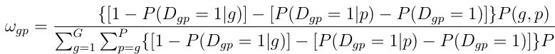

NOTE: contains mathematical notation; text above is the PDF text layer and symbols may be mis-extracted. Image shows the original.

*g*=1

**equation / math rendering (image)**

NOTE: contains mathematical notation; text above is the PDF text layer and symbols may be mis-extracted. Image shows the original.

**equation / math rendering (image)**

NOTE: contains mathematical notation; text above is the PDF text layer and symbols may be mis-extracted. Image shows the original.

**equation / math rendering (image)**

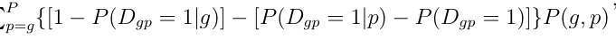

NOTE: contains mathematical notation; text above is the PDF text layer and symbols may be mis-extracted. Image shows the original.

*P*(*Dgp* = 1*|p*) is the fraction of units that are treated in period *p*, *P*(*Dgp* = 1*|g*) is the fraction

of periods in which members of group *g* are treated, *P*(*Dgp* = 1) is the fraction of unit*×*times

that are treated, and *P*(*p, g*) is the population share of observations that correspond to group

*g* and period *p*. This representation can be obtained from Theorem 1 of de Chaisemartin

and D’Haultfœuille (2020), although I present an alternative derivation based on population

regression algebra in Appendix A.<sup>6</sup>

Appearances notwithstanding, this weighting scheme is deeply intuitive. Specification

(2) assumes a conditional expectation function that is linear in group, period, and treatment

status. When misspecified, it will attribute some of the heterogeneous impacts of the treat-

ment to group and period fixed effects.<sup>7</sup> The longer a group’s observed treatment duration

6An immediate implication of (3) is that the weights must sum to one. Another is that *ω*11 = 1 when there is only one treatment group, so the regression differences-in-differences specification (2) identifies the average effect of the treatment on the treated, as noted above.

7This is consistent with the intuition provided by Borusyak and Jaravel (2017), Goodman-Bacon (2018)

7

Page 9

(i.e., the greater *P*(*Dgp* = 1*|g*) is), the more that group’s treatment effects will be absorbed

by group fixed effects. Likewise, the greater the probability of being treated in a particular

period (i.e., the greater *P*(*Dgp* = 1*|p*) is), the more treatment effects experienced during

that period will be absorbed by period effects. Larger groups also receive more weight. I

illustrate these phenomena by simulation in Section 4 and empirically in Section 5.

### **3 A two-stage approach**

In the two-period, two-group case, differences-in-differences regression recovers the difference

in outcomes between treated and untreated units after removing group and period effects,

which under parallel trends represents the average effect of the treatment on the treated.

This is not true when there are multiple groups and periods, since in this case (2) is misspec-

ified for conditional mean outcomes. However, this observation suggests a simple two-stage

average treatment effect estimator for the multiple group and period case. As long there

effect of the treatment on the treated is then identified from a comparison of mean outcomes

between treated and untreated groups, after removing the group and period effects.

Following this logic, a two-stage estimation procedure is

1. Estimate the model

*Ygpit* = *λg* + *γp* + *εgpit*

**equation / math rendering (image)**

NOTE: contains mathematical notation; text above is the PDF text layer and symbols may be mis-extracted. Image shows the original.

on the sample of observations for which *Dgp* = 0, retaining the estimated group and

time effects <sup>ˆ</sup>*λg* and ˆ*γp*.<sup>8</sup>

and de Chaisemartin and D’Haultfœuille (2020) that (2) uses already-treated units as controls for newly treated ones.

8There are variations on this stage of the procedure. It is not necessary to estimate the fixed effects using only untreated observations, any correctly specified conditional mean function will do. For example, one could also use a specification that includes interactions between treatment status and period indicators, or one with group*×*period-specific treatment-status indicators. Since these variations utilize the entire sample to estimate the group and period effects, they may be more efficient. Because treatment status only varies

8

Page 10

2. Regress adjusted outcomes *Ygpit −*<sup>ˆ</sup>*λg −*ˆ*γp* on *Dgp*.

**equation / math rendering (image)**

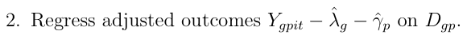

NOTE: contains mathematical notation; text above is the PDF text layer and symbols may be mis-extracted. Image shows the original.

Since parallel trends implies that

*E*(*Ygpit|g, p, Dgp*) *−λg −γp* = *βgpDgp* = *E*(*βgp|Dgp* = 1)*Dgp* + [*βgp −E*(*βgp|Dgp* = 1)]*Dgp,*

**equation / math rendering (image)**

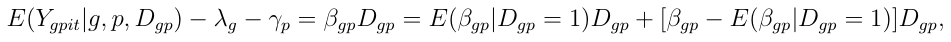

NOTE: contains mathematical notation; text above is the PDF text layer and symbols may be mis-extracted. Image shows the original.

where *E{*[*βgp −E*(*βgp|Dgp* = 1)]*Dgp|Dgp}* = 0, this procedure identifies *E*(*βgp|Dgp* = 1), even

**equation / math rendering (image)**

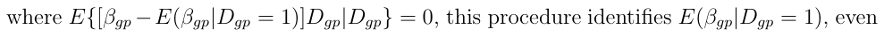

NOTE: contains mathematical notation; text above is the PDF text layer and symbols may be mis-extracted. Image shows the original.

when the adoption and average effects of the treatment are heterogenous with respect to

groups and periods.<sup>9</sup>

Although I prove consistency and unbiasedness in the Appendix, the intuition is straight-

forward. Unbiasedness of the first- (and hence second-) stage estimates follows from standard

arguments. If the (*g, p, i, t*) represent individual-level observations, so does the consistency

of the first stage for the group and period effects. Otherwise, if they represent aggregates

(e.g., state*×*year-level sample averages), then as the number of individual-level observations

used to calculate them increases, the first-stage is equivalent to a population regression of

(*g, p, i, t*)-level means on group and period effects, and hence consistent for those effects. In

either case, the consistency of the second-stage for *E*(*βgp|Dgp* = 1) follows from the consis-

tency of the first stage for the group and period effects.<sup>10</sup>

at the group*×*period level, the group and period effects can also be replaced with fixed effects for individual units and time periods.

**equation / math rendering (image)**

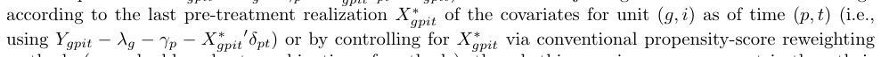

NOTE: contains mathematical notation; text above is the PDF text layer and symbols may be mis-extracted. Image shows the original.

*gpit*

**equation / math rendering (image)**

NOTE: contains mathematical notation; text above is the PDF text layer and symbols may be mis-extracted. Image shows the original.

10Also note that restricting the sample to untreated observations does not introduce sample-selection bias because the selection is with respect treatment status, which is a deterministic function of the group and period variables included in the model.

9

Page 11

#### **3.1 Estimands**

Implemented as described, the two-stage difference-in-differences estimator identifies *E*(*βgp|Dgp* =

1), where the expectation is implicitly taken with respect to all observed units and periods.

This expectation can be expressed as

*E*(*βgp|Dgp* = 1) =

**equation / math rendering (image)**

NOTE: contains mathematical notation; text above is the PDF text layer and symbols may be mis-extracted. Image shows the original.

**equation / math rendering (image)**

NOTE: contains mathematical notation; text above is the PDF text layer and symbols may be mis-extracted. Image shows the original.

*g*=1

**equation / math rendering (image)**

NOTE: contains mathematical notation; text above is the PDF text layer and symbols may be mis-extracted. Image shows the original.

**equation / math rendering (image)**

NOTE: contains mathematical notation; text above is the PDF text layer and symbols may be mis-extracted. Image shows the original.

*p*=*g*

**equation / math rendering (image)**

NOTE: contains mathematical notation; text above is the PDF text layer and symbols may be mis-extracted. Image shows the original.

*βgpP*(*g, p|Dgp* = 1)*.* (4)

**equation / math rendering (image)**

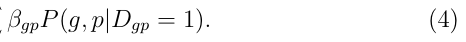

NOTE: contains mathematical notation; text above is the PDF text layer and symbols may be mis-extracted. Image shows the original.

While this is a natural summary measure of group*×*period-specific average treatment effects,

since it reflects the uneven progression of different groups through the course of the treatment,

it may not be especially informative for program evaluation and policy analysis. For example,

even if the effects of the treatment are identical across groups, this measure will put more

weight on groups that are in early stages of the treatment.<sup>11</sup> Callaway and Sant’Anna

(2020) provide a much richer discussion of how heterogeneous average treatment effects can

be summarized.

If there is some treatment duration <sup>¯</sup>*P* which all, or a subset of, groups has completed,

then an alternative summary measure is the <sup>¯</sup>*P*-period average

**equation / math rendering (image)**

NOTE: contains mathematical notation; text above is the PDF text layer and symbols may be mis-extracted. Image shows the original.

*g*=1

**equation / math rendering (image)**

NOTE: contains mathematical notation; text above is the PDF text layer and symbols may be mis-extracted. Image shows the original.

**equation / math rendering (image)**

NOTE: contains mathematical notation; text above is the PDF text layer and symbols may be mis-extracted. Image shows the original.

*p*=*g*

**equation / math rendering (image)**

NOTE: contains mathematical notation; text above is the PDF text layer and symbols may be mis-extracted. Image shows the original.

*βgpP*(*g|Dg* = 1)*/* <sup>¯</sup>*P,* (5)

**equation / math rendering (image)**

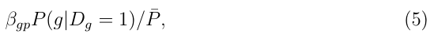

NOTE: contains mathematical notation; text above is the PDF text layer and symbols may be mis-extracted. Image shows the original.

where *P*(*g|Dg* = 1) is the fraction of treated units that belong to group *g*. Because this

measure averages the group-specific average effects of the treatment for a common set of

completed durations, it may provide a more balanced picture of the typical effect of the

treatment, although it ignores the effects of the treatment for durations longer than <sup>¯</sup>*P*

periods. The two-stage procedure can be modified to identify this measure by restricting

the sample used in the second step to untreated observations and treated observations with

11When treatment effects vary by group, it is unclear whether any summary measure will be informative about how the treatment might affect future groups. External validity with this type of heterogeneity is inherently challenging.

10

Page 12

durations no greater than <sup>¯</sup>*P*.

#### **3.2 Event studies**

Difference-in-differences analyses are often accompanied by event-study regressions of the

form

*Ygpit* = *λg* + *γp* +

**equation / math rendering (image)**

NOTE: contains mathematical notation; text above is the PDF text layer and symbols may be mis-extracted. Image shows the original.

**equation / math rendering (image)**

NOTE: contains mathematical notation; text above is the PDF text layer and symbols may be mis-extracted. Image shows the original.

*r*=*−R*

**equation / math rendering (image)**

NOTE: contains mathematical notation; text above is the PDF text layer and symbols may be mis-extracted. Image shows the original.

*βrDrgp* + *εgpit,* (6)

**equation / math rendering (image)**

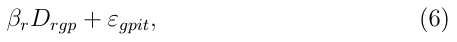

NOTE: contains mathematical notation; text above is the PDF text layer and symbols may be mis-extracted. Image shows the original.

where for *r ≤*0 the *Drgp ∈{D−Rgp, . . . , D*0*gp}* are (*r*+1)-period leads of treatment adoption,

**equation / math rendering (image)**

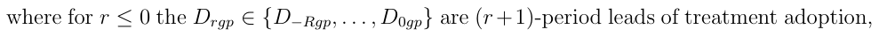

NOTE: contains mathematical notation; text above is the PDF text layer and symbols may be mis-extracted. Image shows the original.

and for *r >* 0 the *Drgp ∈{D*1*gp, . . . , DPgp}* are indicators for *r*-period treatment durations.<sup>12</sup>

**equation / math rendering (image)**

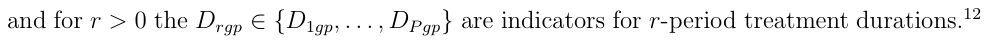

NOTE: contains mathematical notation; text above is the PDF text layer and symbols may be mis-extracted. Image shows the original.

In principle, such regressions serve a dual purpose. First, they can be used to show how

the effect of the treatment evolves over the course of the treatment. Second, the coefficients

on the treatment adoption leads can be used as placebo tests for the plausibility of parallel

trends.

Sun and Abraham (2020) show that, when duration-specific average treatment effects

vary across groups¢, event-study regressions suffer from the same problem as difference-in-

differences regressions. This can be seen using an argument similar to the one presented for

difference-in-differences regressions in Section 2.1. Let *Yrgpit* denote potential outcomes after

*r* periods of treatment, and *βrgp* = *E*(*Yrgpit −Y*0*gpit|g, p, Drgp* = 1) be the average effect of

**equation / math rendering (image)**

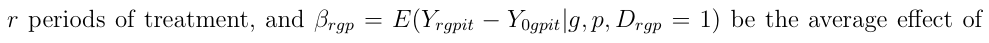

NOTE: contains mathematical notation; text above is the PDF text layer and symbols may be mis-extracted. Image shows the original.

being treated for *r* periods for members of group *g* in time period *p*.<sup>13</sup> Under parallel trends,

we can write

*E*[*Ygpit|g, p,* (*Drgp*)] = *λg* +*γp* +

**equation / math rendering (image)**

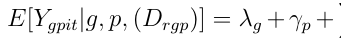

NOTE: contains mathematical notation; text above is the PDF text layer and symbols may be mis-extracted. Image shows the original.

**equation / math rendering (image)**

NOTE: contains mathematical notation; text above is the PDF text layer and symbols may be mis-extracted. Image shows the original.

*r*=1

**equation / math rendering (image)**

NOTE: contains mathematical notation; text above is the PDF text layer and symbols may be mis-extracted. Image shows the original.

*E*(*βrgp|Drgp* = 1)*Drpg* +

**equation / math rendering (image)**

NOTE: contains mathematical notation; text above is the PDF text layer and symbols may be mis-extracted. Image shows the original.

*P* X

**equation / math rendering (image)**

NOTE: contains mathematical notation; text above is the PDF text layer and symbols may be mis-extracted. Image shows the original.

*r*=1

**equation / math rendering (image)**

NOTE: contains mathematical notation; text above is the PDF text layer and symbols may be mis-extracted. Image shows the original.

[*βrgp −E*(*βrgp|Drgp* = 1)]*Drgp,*

**equation / math rendering (image)**

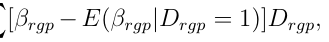

NOTE: contains mathematical notation; text above is the PDF text layer and symbols may be mis-extracted. Image shows the original.

12In event-study regressions, it is common practice to use calendar times *t* in place of more coarse treatment periods *p*.

13There is a one-to-one correspondence between duration- and period-specific treatment effects. In terms of the group*×*period average treatment effects *βgp*, the duration-specific effects satisfy *βrgp* = *βg,p−g*+1. While in principle the duration-specific average treatment effects for each group might vary over time, in practice we only ever observe each treatment duration at most once for each group.

11

Page 13

where, in general, *E{*<sup>P</sup>*<sup>P</sup>*

**equation / math rendering (image)**

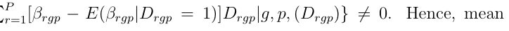

NOTE: contains mathematical notation; text above is the PDF text layer and symbols may be mis-extracted. Image shows the original.

outcomes are not necessarily linear in group, period, and treatment-duration indicators, so

the coefficients on the *Drgp* from (6) do not identify the average effects of being treated

for *r* periods. Sun and Abraham (2020) further show that the coefficients on the adoption

leads and duration indicators identify weighted averages of all of the group*×*period-specific

average treatment effects. An important consequence of this is that the coefficients on the

treatment-adoption leads *Drgp*, *r ≤*0, may be nonzero even if trends are, in fact, parallel.

The two-stage procedure developed above can be extended to the event-study setting by

amending the second stage of the procedure to:

2’. Regress *Ygpit −*<sup>ˆ</sup>*λg −*ˆ*γp* on *D−Rgp, . . . , D*0*gt, . . . , DPgp*.

**equation / math rendering (image)**

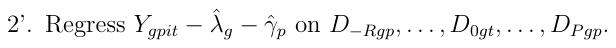

NOTE: contains mathematical notation; text above is the PDF text layer and symbols may be mis-extracted. Image shows the original.

Following the logic of the previous section, because *E*[*Ygpit|g, p,* (*Drgp*)] *−λg −γp* is linear in

the *Drgp*, the coefficients on the *Drgp* identify the average effects *E*(*βrgp|Drgp* = 1).<sup>14</sup>

#### **3.3 Inference**

The standard errors for the two-stage estimators need to be adjusted to account for the fact

that the dependent variable *Ygpit −*<sup>ˆ</sup>*λg −*ˆ*γp* in the second-stage is generated using estimates

obtained from the first stage of the procedure (Dumont et al., 2005). The asymptotic distri-

bution of the second-stage estimates can obtained by interpreting the two-stage procedure

as a joint GMM estimator (Hansen, 1982).

Let *Wgpit* = [*Ygpit,* (1(*g*)*gpit*)*,* (1(*p*)*gpit*)*, Dgp*] denote the data for observation (*g, p, i, t*),

**equation / math rendering (image)**

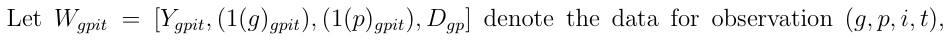

NOTE: contains mathematical notation; text above is the PDF text layer and symbols may be mis-extracted. Image shows the original.

consisting of the outcome *Ygpit*, the *G*-vector of group-membership indicators (1(*g*)*gpit*),

a *P*-vector (1(*p*)*gpit*) of period indicators for periods *p ∈{*1*, . . . , P}*, and the treatment-

status indicator *Dgp*. Let *λ* be the *G*-vector of group fixed effects, *γ* the *P*-vector of period

14This expectation is taken over all groups with durations of at least *r*. Since under staggered adoption the completed treatment duration varies by group, the groups over which these duration-specific effects are averaged will vary across durations. These averages are also what the interaction-weighted estimator proposed by Sun and Abraham (2020) identifies. If all groups are treated for at least <sup>¯</sup>*P* periods, an alternative is to exclude observations corresponding to treatment durations longer than <sup>¯</sup>*P* periods from the second-stage sample, in which case the two-stage approach identifies duration-specific treatment effects, averaged over all groups.

12

Page 14

fixed effects, and *β* the group*×*period average treatment effect. The two-stage difference-in-

differences estimator solves the population analog of the moment condition

**equation / math rendering (image)**

NOTE: contains mathematical notation; text above is the PDF text layer and symbols may be mis-extracted. Image shows the original.

**equation / math rendering (image)**

NOTE: contains mathematical notation; text above is the PDF text layer and symbols may be mis-extracted. Image shows the original.

**equation / math rendering (image)**

NOTE: contains mathematical notation; text above is the PDF text layer and symbols may be mis-extracted. Image shows the original.

[*Ygpit −*(1(*g*)*gpit*)*<sup>′</sup>λ −*(1(*p*)*gpit*)*<sup>′</sup>γ*][(1(*g*)*gpit*)*,* (1(*p*)*gpit*)]*<sup>′</sup>*(1 *−Dgp*)

**equation / math rendering (image)**

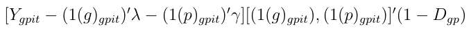

NOTE: contains mathematical notation; text above is the PDF text layer and symbols may be mis-extracted. Image shows the original.

[*Ygpit −*(1(*g*)*gpit*)*<sup>′</sup>λ −*(1(*p*)*gpit*)*<sup>′</sup>γ −βDgp*]*Dgp*

**equation / math rendering (image)**

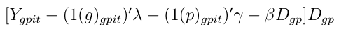

NOTE: contains mathematical notation; text above is the PDF text layer and symbols may be mis-extracted. Image shows the original.

**equation / math rendering (image)**

NOTE: contains mathematical notation; text above is the PDF text layer and symbols may be mis-extracted. Image shows the original.

= 0*.*

**equation / math rendering (image)**

NOTE: contains mathematical notation; text above is the PDF text layer and symbols may be mis-extracted. Image shows the original.

By Theorem 6.1 of Newey and McFadden (1994, cf. Newey, 1984), and under standard

regularity conditions,

**equation / math rendering (image)**

NOTE: contains mathematical notation; text above is the PDF text layer and symbols may be mis-extracted. Image shows the original.

*N*(<sup>ˆ</sup>*β −β*)

**equation / math rendering (image)**

NOTE: contains mathematical notation; text above is the PDF text layer and symbols may be mis-extracted. Image shows the original.

*a∼N*(0*, v*), where *v* is the last element of

*E*

**equation / math rendering (image)**

NOTE: contains mathematical notation; text above is the PDF text layer and symbols may be mis-extracted. Image shows the original.

**equation / math rendering (image)**

NOTE: contains mathematical notation; text above is the PDF text layer and symbols may be mis-extracted. Image shows the original.

*∂*(*λ, γ, β*)

**equation / math rendering (image)**

NOTE: contains mathematical notation; text above is the PDF text layer and symbols may be mis-extracted. Image shows the original.

**equation / math rendering (image)**

NOTE: contains mathematical notation; text above is the PDF text layer and symbols may be mis-extracted. Image shows the original.

*E*[*f*(*λ, γ, β*; *Wgpit*)*f*(*λ, γ, β*; *Wgpit*)*<sup>′</sup>*]*E*

**equation / math rendering (image)**

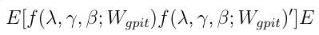

NOTE: contains mathematical notation; text above is the PDF text layer and symbols may be mis-extracted. Image shows the original.

*∂f*(*λ, γ, β*; *Wgpit*)

**equation / math rendering (image)**

NOTE: contains mathematical notation; text above is the PDF text layer and symbols may be mis-extracted. Image shows the original.

*∂*(*λ, γ, β*)

**equation / math rendering (image)**

NOTE: contains mathematical notation; text above is the PDF text layer and symbols may be mis-extracted. Image shows the original.

**equation / math rendering (image)**

NOTE: contains mathematical notation; text above is the PDF text layer and symbols may be mis-extracted. Image shows the original.

*.*

**equation / math rendering (image)**

NOTE: contains mathematical notation; text above is the PDF text layer and symbols may be mis-extracted. Image shows the original.

Asymptotics for variations on the two-stage difference-in-differences estimator (such as the

event-study version) are similar.

The preceding expression can be used to manually correct the estimated second-stage

variances for the use of a generated dependent variable. With modern statistical software, a

simpler approach is to estimate both stages of the procedure simultaneously using a GMM

routine. In Appendix B, I provide example Stata syntax that shows how to implement

the two-stage difference-in-differences approach (with valid asymptotic standard errors) via

GMM.

### **4 Simulations**

To illustrate the effectiveness of the two-stage approach, I conduct two Monte Carlo studies.

For each study, I simulate 250 datasets, each consisting of observations on 50 units over 10

periods. Unit-level outcomes are determined by

*Ygpit* = *λi* + *γt* + *βgpDgp* + *εgpit,*

**equation / math rendering (image)**

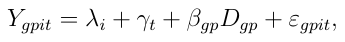

NOTE: contains mathematical notation; text above is the PDF text layer and symbols may be mis-extracted. Image shows the original.

13

Page 15

with *λi, εit ∼N*(0*,* 1). I assume that the average effect of the treatment varies by group

and period, with the treatment effects for each group stabilizing by the fourth period.<sup>15</sup> For

the first study, three treatment groups, each consisting of five units, adopt the treatment at

times 4, 5, and 6, respectively. The only difference for the second study is that the sizes of

the treatment groups vary, consisting of 5, 15, and 10 units.

Focusing initially on the first simulation, Figure 1 plots the weights that the regression

difference-in-differences specification (2) places on each of the group*×*period-specific treat-

ment effects (here, I have aligned the weights by the calendar time, rather than the time since

adoption). For the first two groups, the weight that (2) places on period-specific treatment

effects decreases with each successive period, until the final group adopts the treatment and

the treated share of units stabilizes. After this stabilization, treatment effects for earlier

groups, who are treated for more periods, receive less weight. This is consistent with the

theoretical predictions and intuition from Section 2.2.

Table 1 presents the means and standard deviations of estimates of several average treat-

ment effect measures. Results for the first simulation are presented in the first column. The

first row of the top panel of the table presents the true group*×*period average treatment

effect (i.e., (4)). The difference-in-differences regression estimate, which as (3) shows and

Figure 1 illustrates, tends to put more weight on earlier treatment durations, understates

the true average effect considerably.

The third row summarizes estimates of the group*×*period average, obtained by estimat-

ing models with separate treatment-status indicators for each group and period (as well as

unit and time fixed effects), then aggregating the group*×*period-specific average effects ac-

cording to the empirical distribution of treated groups and periods (i.e., the sample analog

of (4)). Finally, the fourth row summarizes two-stage difference-in-difference regression es-

timates, obtained following the procedure outlined in Section 3. In this case, the two-stage

estimates are indistinguishable from the aggregated estimates. Both perform well for the

15The vectors of average treatment effects for the first four periods are (2, 4, 6, 8), (1, 2, 3, 4), and (.5, 1, 3, 3.5) for groups one, two, and three.

14

Page 16

true group*×*period average treatment effect.

As I note in Section 3.1, the group*×*period average treatment effect might not be the best

way to summarize the effect of the treatment. Since all units in this simulation are treated

for at least four periods, it is possible to estimate a four-period treatment effect, averaged

across all treated groups. The first row of the bottom panel of Table 1 presents the true

four-period average.<sup>16</sup> The second row presents estimates aggregated from regressions that

include group*×*period-specific treatment indicators (i.e., the sample analog of (5)).

The third row presents stacked difference-in-differences regression estimates of this av-

erage. To implement the stacked estimator, for each treated group I create a new dataset

spanning two periods before and four periods after that group adopts the treatment, con-

sisting of observations on the treatment group and the group of units that never receives

the treatment. I then stack these group-specific datasets and regress outcomes on treatment

status and dataset-specific group and period effects.<sup>17</sup>

Finally, the fourth row presents two-stage difference-in-difference estimates, obtained by

restricting the second stage to the sample of observations with treatment durations no greater

than four periods. Here, the aggregated, stacked, and two-stage estimates are identical; all

are centered closely on the true four-period average effect.

The sole difference between the first and second studies is that, in the second, the sizes

of the treatment groups vary. The results for this study are presented in the second column

of the table. Here, the relative performance of the aggregated and two-stage estimators for

the group*×*period average treatment effect is similar to the first study. For the four-period

average, the aggregated and two-stage estimates are again identical, and close to the true

average. In contrast, the stacked estimator, which weights each group’s average treatment

effect by dataset-specific treatment variance and sample size (see Appendix A), slightly

16Because the difference-in-difference regression estimate represents a weighted average of all observed group*×*period treatment effects, it is not directly comparable to this four-period average.

17In some applications, treated units who have not yet adopted the treatment are also included as controls in each group-specific dataset. While it is possible to use the stacked approach to estimate a weighted group*×*period average treatment effect, in most applications the group-specific datasets include the same number of treatment periods for each group.

15

Page 17

overstates the true average.

The top panel of Figure 2 summarizes estimates from event-study regressions that include

two leads of treatment adoption. The top panel of the figure plots the average point estimates

(and standard deviations) from the standard event-study specification (6). Even though the

data-generating process satisfies parallel trends, because the group*×*period-specific average

treatment effects are heterogeneous, the estimated leads of adoption exhibit a pre-treatment

dip in outcomes, creating the mistaken appearance of a violation of parallel trends. This is

consistent with the results of Sun and Abraham (2020) and the discussion in Section 3.2.

The second panel summarizes estimates obtained by manually aggregating group*×*duration-

specific average treatment effects across groups, and the third summarizes estimates from

the two-stage event-study procedure outlined in Section 3.2. The aggregated and two-stage

results are nearly identical; both present an accurate picture of pre-treatment trends, as

well as the evolution of the effect of the treatment over its course (I present the means and

standard deviations of the point estimates in Appendix Table 3).

### **5 Empirical application**

To illustrate the application of the results presented above, I revisit Autor’s (2003) analysis

of the effect of court rulings limiting the doctrine of employment at will on the growth of

the temporary help services sector (THS). The key data are observations on the log of state-

level THS employment and indicators for state-level legal exceptions to employment at will

between 1979 and 1995. The baseline difference-in-differences specification regresses THS

employment on an exception indicator and state and year effects. The estimate, reported in

Following the discussion above, if the effect of the treatment is heterogeneous across

18Autor’s (2003) preferred specifications include additional covariates and state-specific linear time trends, which I ignore for simplicity.

16

Page 18

treatment groups and periods, the difference-in-differences regression estimate represents a

difficult-to-interpret weighted average of group*×*period treatment effects. The first group

in this application is treated in 1979, and the treatment is initiated for additional groups

in every year through 1988, for a total of 10 groups. The difference-in-differences estimate

therefore places nonzero weight on 125 group*×*period-specific treatment effects. The top

panel of Figure 3 plots the distribution of these weights. Some are negative, although more

are positive, and the positive magnitudes tend to exceed the negative ones. The distribution

is also skewed, with a handful of effects receiving relatively large weights. The bottom panel

of the figure plots the weights themselves for the first five groups. Consistent with the results

in Section 2.2 (and the literature cited there), differences in differences places more weight

on treatment effects for groups that are treated earlier, that occur in earlier in the course of

the treatment for each group, and for larger groups.

As a point of comparison to the difference-in-differences regression estimate, Table 2 also

presents an estimate of the group*×*period average treatment effect, obtained by estimating

models with separate treatment indicators for each treated group and period, then averag-

ing the coefficients on those indicators according to the empirical distribution of groups and

periods among treated units.<sup>19</sup> The aggregated point estimate of about .09 is somewhat

smaller than the difference-in-differences regression estimate. Since the results below (which

agree with Autor’s original findings) show that the effects of the treatment tend to be some-

what larger in the first few periods after the treatment, this is consistent with the weights

illustrated above. At the same time, the broad similarity between the difference-in-difference

and aggregated estimates suggests that the effects of the treatment are fairly homogeneous

across groups and over time.

Table 2 also presents a two-stage difference-in-differences estimate of this treatment effect,

obtained by estimating both equations simultaneously via GMM (and clustering standard

19For this, and all subsequent, estimates, I exclude units that were already treated in 1979, the first year of the sample, since no treatment effects are identified for this group. I calculate standard error for the aggregated estimator using the delta method, taking the distribution of groups and periods among the treated as fixed, and using state-clustered standard errors for the group*×*period-specific regression coefficients.

17

Page 19

errors at the state level). The two-stage estimate is similar to the aggregated estimate,

illustrating the effectiveness of the two-stage approach. The table also presents the results

from a version of the two-stage estimator in which a correctly specified first-stage equation

that includes interactions between treatment status and period indicators is estimated using

the full sample. The second-stage estimate is similar to the previous two-stage estimate (for

which the first stage consists of a regression of untreated outcomes on state and time effects

alone), although the standard error is slightly smaller.

As I note in Section 3.1, the treatment effects estimated above are averaged across groups

with different completed treatment durations. Because the shortest observed treatment

duration is eight periods, it is possible to average the group-specific eight-period average

treatment effects over all treatment groups. The aggregated estimate of this treatment

effect is about .11. Consistent with the larger estimated early-duration treatment effects

presented below, this is somewhat larger than the preceding estimate, which is averaged

across all treated groups and periods. I also implement a stacked difference-in-differences

estimator for this average effect, in which the dataset for each treatment group consists of

observations on that group and the group of never-treated observations, one period before

through eight periods after the adoption of the treatment. The resulting estimate is also

about .11. Finally, I estimate this effect by the two-stage difference in differences by simply

restricting the second-stage estimation sample to untreated observations and those with

completed durations of eight periods or fewer. The two-stage and stacked estimates are also

similar.

Autor (2003) also estimates an event-study regression to test the plausibility of parallel

trends. To replicate this, I estimate a standard event-study regression using a version of

specification (6) that includes two leads of treatment adoption. The top panel of Figure 4

plots the coefficient estimates for these leads and the first eight post-treatment periods (I

present the full set of point estimates in Appendix Table 4). The estimates suggest that the

effect of the treatment is larger in periods nearer adoption, stabilizing to a smaller value for

18

Page 20

durations of four or more periods. To examine the effect of heterogeneity on the event-study

estimates, I also perform an aggregated event study using a model that includes separate

duration-specific effects for each treatment group, following Sun and Abraham (2020).<sup>20</sup> The

results, presented in the second panel of the figure, are similar to those from the event study

that ignores treatment groups, suggesting that there is little heterogeneity in the duration-

specific effects with respect to the timing of adoption. Finally, the bottom panel of the figure

plots the results from a two-stage event study, obtained by replacing treatment status in the

second stage of the procedure with indicators for each treatment duration. Once again, the

two-stage estimates are similar to the aggregated estimates.

### **6 Conclusion**

When adoption of a treatment is staggered across time, and the average effects of the treat-

ment vary by group and period, the usual difference-in-differences regression specification

does not identify an easily interpretable measure of the typical effect of the treatment. When

the duration-specific effects are also heterogeneous, neither do the coefficients from the usual

event-study specification. The ultimate source of these identification failures is that outcomes

are not necessarily linear in group, period and treatment status, as difference-in-differences

and event-study regression specifications assume.

The two-stage approach developed in this paper is motivated by the observation that,

under parallel trends, untreated outcomes are linear in group and period effects. Those

effects are therefore identified from a first-stage regression estimated using the sample of

untreated observations. The average effect of the treatment on the treated is then identified

from a regression of outcomes on treatment status, after removing group and period effects.

This procedure is robust to the presence of heterogeneous treatment effects when treatment

adoption is staggered. It is also simple and intuitive, and can be extended to identify a variety

20To implement this, I exclude the second and third treatment groups, for which two leads of adoption are not observed, and average the first eight duration-specific effects over the remaining seven groups, weighted by cohort size.

19

Page 21

of different treatment effect measures. Monte Carlo simulations and an empirical example

show that the two-stage estimators correctly identify informative average treatment effect

measures, in some cases outperforming alternative estimators that are also more difficult to

implement.

### **Appendix A: Proofs**

#### **Consistency and unbiasedness**

*Consistency.* The consistency of (<sup>ˆ</sup>*λg,* ˆ*γp*) for (*λg, γp*) follows from (1) and standard least-

squares consistency arguments if *G* and *P* are fixed as the sample size grows. Otherwise, if

the *Ygpit* represent sample averages calculated using *Ngpit* observations, then under stan-

dard conditions, *Ygpit*

*p−→E*(*Ygpit|g, p, i, t*) as *Ngpit →∞*. Since, under parallel trends,

**equation / math rendering (image)**

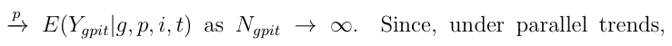

NOTE: contains mathematical notation; text above is the PDF text layer and symbols may be mis-extracted. Image shows the original.

*E*[*E*(*Ygpit|g, p, i, t*)*|g, p*] = *λg* + *γp*, (<sup>ˆ</sup>*λg,* ˆ*γp*)

**equation / math rendering (image)**

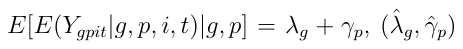

NOTE: contains mathematical notation; text above is the PDF text layer and symbols may be mis-extracted. Image shows the original.

*p−→*(*λg, γp*) by the continuous mapping theorem.

In either case, *Ygpit −*<sup>ˆ</sup>*λg −*<sup>ˆ</sup>*λp*

**equation / math rendering (image)**

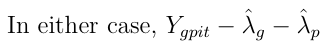

NOTE: contains mathematical notation; text above is the PDF text layer and symbols may be mis-extracted. Image shows the original.

*p−→E*(*Ygpit|g, p, i, t*) *−λg −γp*. Since *E*[*E*(*Ygpit|g, p, i, t*)*|g, p*] *−*

**equation / math rendering (image)**

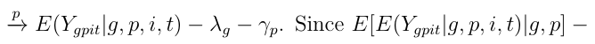

NOTE: contains mathematical notation; text above is the PDF text layer and symbols may be mis-extracted. Image shows the original.

*λg −γp* = *βgpDgp* is linear in *Dgp*, the second stage coefficient is consistent for *E*(*βgp|Dgp* = 1)

by the continuous mapping theorem.

*Unbiasedness.* From standard arguments applied to the first stage, *E*[(<sup>ˆ</sup>*λg,* ˆ*γt*)*|g, p, Dgp*] =

*E*[(<sup>ˆ</sup>*λg,* ˆ*γt*)*|g, p*] = (*λg, γt*). Hence we can write *Ygpit −*<sup>ˆ</sup>*λg −*ˆ*γt* = *E*(*βgp|Dgp* = 1)*Dgp* + *Ugpit*

**equation / math rendering (image)**

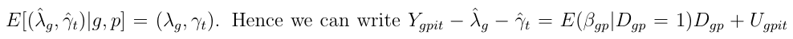

NOTE: contains mathematical notation; text above is the PDF text layer and symbols may be mis-extracted. Image shows the original.

where *E*(*Ugpit|Dgp*) = *E*[*E*(*Ugpit|g, p, Dgp*)*|Dgp*] = 0, which implies that the second-stage is

**equation / math rendering (image)**

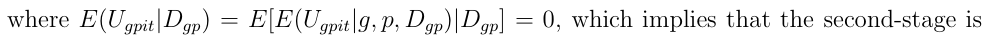

NOTE: contains mathematical notation; text above is the PDF text layer and symbols may be mis-extracted. Image shows the original.

unbiased for *E*(*βgp|Dgp* = 1).

**equation / math rendering (image)**

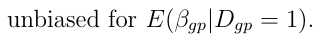

NOTE: contains mathematical notation; text above is the PDF text layer and symbols may be mis-extracted. Image shows the original.

#### **The regression DD estimand** (3)

From (1), we can write

*Ygpit* = *λg* + *γp* +

**equation / math rendering (image)**

NOTE: contains mathematical notation; text above is the PDF text layer and symbols may be mis-extracted. Image shows the original.

*G* X

**equation / math rendering (image)**

NOTE: contains mathematical notation; text above is the PDF text layer and symbols may be mis-extracted. Image shows the original.

*h*=1

**equation / math rendering (image)**

NOTE: contains mathematical notation; text above is the PDF text layer and symbols may be mis-extracted. Image shows the original.

*P* X

**equation / math rendering (image)**

NOTE: contains mathematical notation; text above is the PDF text layer and symbols may be mis-extracted. Image shows the original.

*q*=*h*

**equation / math rendering (image)**

NOTE: contains mathematical notation; text above is the PDF text layer and symbols may be mis-extracted. Image shows the original.

*βhq*1(*h, q*)*gpit* + *εgpit,* (7)

**equation / math rendering (image)**

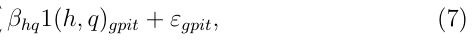

NOTE: contains mathematical notation; text above is the PDF text layer and symbols may be mis-extracted. Image shows the original.

20

Page 22

where 1(*h, q*)*gpit* is an indicator for whether observation (*g, p, i, t*) corresponds to group *h*

and period *q*, and *E*[*εgpit|g, p,* (1(*h, q*)*gpit*)] = 0.

**equation / math rendering (image)**

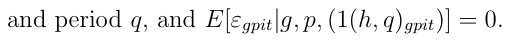

NOTE: contains mathematical notation; text above is the PDF text layer and symbols may be mis-extracted. Image shows the original.

Let <sup>˜</sup>*Dgp* denote the residual from a population regression of *Dgp* on group and period

fixed effects. By the Frisch-Waugh-Lovell theorem, the coefficient on *Dgp* from a population

regression of *Ygpit* on *Dgp* and group and period effects is

**equation / math rendering (image)**

NOTE: contains mathematical notation; text above is the PDF text layer and symbols may be mis-extracted. Image shows the original.

*E*( <sup>˜</sup>*D*<sup>2</sup>

**equation / math rendering (image)**

NOTE: contains mathematical notation; text above is the PDF text layer and symbols may be mis-extracted. Image shows the original.

*gp*<sup>)</sup>

**equation / math rendering (image)**

NOTE: contains mathematical notation; text above is the PDF text layer and symbols may be mis-extracted. Image shows the original.

=

*E*[ <sup>˜</sup>*Dgp*

**equation / math rendering (image)**

NOTE: contains mathematical notation; text above is the PDF text layer and symbols may be mis-extracted. Image shows the original.

**equation / math rendering (image)**

NOTE: contains mathematical notation; text above is the PDF text layer and symbols may be mis-extracted. Image shows the original.

*h*=1

**equation / math rendering (image)**

NOTE: contains mathematical notation; text above is the PDF text layer and symbols may be mis-extracted. Image shows the original.

P*P*

**equation / math rendering (image)**

NOTE: contains mathematical notation; text above is the PDF text layer and symbols may be mis-extracted. Image shows the original.

**equation / math rendering (image)**

NOTE: contains mathematical notation; text above is the PDF text layer and symbols may be mis-extracted. Image shows the original.

*E*( <sup>˜</sup>*D*<sup>2</sup>

**equation / math rendering (image)**

NOTE: contains mathematical notation; text above is the PDF text layer and symbols may be mis-extracted. Image shows the original.

*gp*<sup>)</sup>

**equation / math rendering (image)**

NOTE: contains mathematical notation; text above is the PDF text layer and symbols may be mis-extracted. Image shows the original.

=

*G* X

**equation / math rendering (image)**

NOTE: contains mathematical notation; text above is the PDF text layer and symbols may be mis-extracted. Image shows the original.

*h*=1

**equation / math rendering (image)**

NOTE: contains mathematical notation; text above is the PDF text layer and symbols may be mis-extracted. Image shows the original.

*P* X

**equation / math rendering (image)**

NOTE: contains mathematical notation; text above is the PDF text layer and symbols may be mis-extracted. Image shows the original.

*q*=*h*

**equation / math rendering (image)**

NOTE: contains mathematical notation; text above is the PDF text layer and symbols may be mis-extracted. Image shows the original.

*E*[ <sup>˜</sup>*Dgp*1(*h, q*)*gpit*]

**equation / math rendering (image)**

NOTE: contains mathematical notation; text above is the PDF text layer and symbols may be mis-extracted. Image shows the original.

*E*( <sup>˜</sup>*D*<sup>2</sup>

**equation / math rendering (image)**

NOTE: contains mathematical notation; text above is the PDF text layer and symbols may be mis-extracted. Image shows the original.

*gp*<sup>)</sup>

**equation / math rendering (image)**

NOTE: contains mathematical notation; text above is the PDF text layer and symbols may be mis-extracted. Image shows the original.

*βhq*

**equation / math rendering (image)**

NOTE: contains mathematical notation; text above is the PDF text layer and symbols may be mis-extracted. Image shows the original.

=

*G* X

**equation / math rendering (image)**

NOTE: contains mathematical notation; text above is the PDF text layer and symbols may be mis-extracted. Image shows the original.

*g*=1

**equation / math rendering (image)**

NOTE: contains mathematical notation; text above is the PDF text layer and symbols may be mis-extracted. Image shows the original.

*P* X

**equation / math rendering (image)**

NOTE: contains mathematical notation; text above is the PDF text layer and symbols may be mis-extracted. Image shows the original.

*p*=*g*

**equation / math rendering (image)**

NOTE: contains mathematical notation; text above is the PDF text layer and symbols may be mis-extracted. Image shows the original.

*ωgpβgp.*

**equation / math rendering (image)**

NOTE: contains mathematical notation; text above is the PDF text layer and symbols may be mis-extracted. Image shows the original.

where *ωgp* is the coefficient from a regression of 1(*h, q*)*gpit* on *Dgp* and group and period fixed

effects. The second equality uses the facts that *εgpit* is mean-independent of the regressors

and that <sup>˜</sup>*Dgp* is uncorrelated with group and period effects by construction.<sup>21</sup>

The weight *ωgp* that difference in differences places on *βgp* is the coefficient on *Dgp* from

a regression of 1(*g, p*)*gpit* on *Dgp* and group and period fixed effects. By the Frisch-Waugh-

Lovell theorem, this is equivalent to the slope coefficient from a population regression of

1(*g, p*)*gpit* on the residual from an auxiliary regression of *Dgp* on group and period effects.

Using the two-way within or double-demeaned transformation, this residual can be expressed

as

˜*Dgp* = [*Dgp −P*(*Dgp* = 1*|g*)] *−*[*P*(*Dgp* = 1*|p*) *−P*(*Dgp* = 1)]*.* (8)

**equation / math rendering (image)**

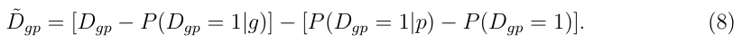

NOTE: contains mathematical notation; text above is the PDF text layer and symbols may be mis-extracted. Image shows the original.

*h*=1

**equation / math rendering (image)**

NOTE: contains mathematical notation; text above is the PDF text layer and symbols may be mis-extracted. Image shows the original.

P*P*

**equation / math rendering (image)**

NOTE: contains mathematical notation; text above is the PDF text layer and symbols may be mis-extracted. Image shows the original.

21

Page 23

Since *E*( <sup>˜</sup>*D*<sup>2</sup>

**equation / math rendering (image)**

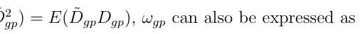

NOTE: contains mathematical notation; text above is the PDF text layer and symbols may be mis-extracted. Image shows the original.

**equation / math rendering (image)**

NOTE: contains mathematical notation; text above is the PDF text layer and symbols may be mis-extracted. Image shows the original.

*V ar*( <sup>˜</sup>*Dgp*)

**equation / math rendering (image)**

NOTE: contains mathematical notation; text above is the PDF text layer and symbols may be mis-extracted. Image shows the original.

**equation / math rendering (image)**

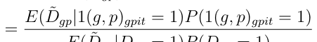

NOTE: contains mathematical notation; text above is the PDF text layer and symbols may be mis-extracted. Image shows the original.

*E*( <sup>˜</sup>*Dgp|Dgp* = 1)*P*(*Dgp* = 1)

**equation / math rendering (image)**

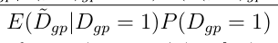

NOTE: contains mathematical notation; text above is the PDF text layer and symbols may be mis-extracted. Image shows the original.

**equation / math rendering (image)**

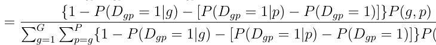

NOTE: contains mathematical notation; text above is the PDF text layer and symbols may be mis-extracted. Image shows the original.

*g*=1

**equation / math rendering (image)**

NOTE: contains mathematical notation; text above is the PDF text layer and symbols may be mis-extracted. Image shows the original.

P*P*

**equation / math rendering (image)**

NOTE: contains mathematical notation; text above is the PDF text layer and symbols may be mis-extracted. Image shows the original.

**equation / math rendering (image)**

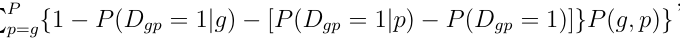

NOTE: contains mathematical notation; text above is the PDF text layer and symbols may be mis-extracted. Image shows the original.

*,*

**equation / math rendering (image)**

NOTE: contains mathematical notation; text above is the PDF text layer and symbols may be mis-extracted. Image shows the original.

where the final equality uses (8).

#### **6.1 Stacked differences in differences**

In the stacked approach, a new dataset is created for each treated group, containing obser-

vations on that group <sup>¯</sup>*R* periods before, and <sup>¯</sup>*P* periods after, the treatment is adopted, as

well as on units that are not yet treated during these periods. These group-specific datasets

are stacked, and outcomes are regressed on treatment status and dataset-specific group and

period fixed effects:

*Ycgpit* = *λcg* + *λcp* + *βDcgp* + *εcgpit,*

**equation / math rendering (image)**

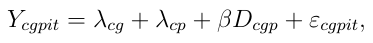

NOTE: contains mathematical notation; text above is the PDF text layer and symbols may be mis-extracted. Image shows the original.

where *cgpit* indexes the value of an observation in the dataset for group *c* for the *i*th member

of group *g* during the *t*th time of period *p*.

Let *Dcgp* be an indicator for whether group *g* is treated during period *p* of the group-*c*

dataset, and *Drcgp* be an indicator for whether members of *g* have been treated for *r ∈*

*{*1*, . . . ,* <sup>¯</sup>*P}* periods as of period *p* in dataset *c*. Let *τ* = <sup>¯</sup>*P/*( <sup>¯</sup>*P* + <sup>¯</sup>*R* + 1) denote the fraction of

periods during which treated units in any group-specific dataset are treated, *πc* denote the

fraction of units in dataset *c* that belong to the treatment group, and *ρc* denote size of the

group-*c* dataset relative to the stacked dataset.

The weight *ωrg* that stacked differences in differences places on the *r*-period average

treatment effect *βrg* for group *g* is given by the slope coefficient from a population regression

of *Drcgp* on the residual <sup>˜</sup>*Dcgp* from a regression of *Dcgp* on dataset*×*period and dataset*×*group

22

Page 24

effects. This residual is

˜*Dcgp* = *Dcgp −P*(*Dcgp* = 1*|g, c*) *−*[*P*(*Dcgp* = 1*|p, c*) *−P*(*Dcgp* = 1*|c*)]*,*

**equation / math rendering (image)**

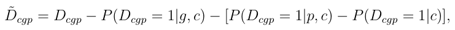

NOTE: contains mathematical notation; text above is the PDF text layer and symbols may be mis-extracted. Image shows the original.

where statements conditional on *c* are true in the population corresponding to dataset *c*.

Using this expression and adapting (3) to the stacked setting,

**equation / math rendering (image)**

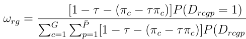

NOTE: contains mathematical notation; text above is the PDF text layer and symbols may be mis-extracted. Image shows the original.

**equation / math rendering (image)**

NOTE: contains mathematical notation; text above is the PDF text layer and symbols may be mis-extracted. Image shows the original.

NOTE: contains mathematical notation; text above is the PDF text layer and symbols may be mis-extracted. Image shows the original.

**equation / math rendering (image)**

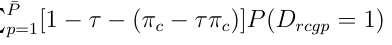

NOTE: contains mathematical notation; text above is the PDF text layer and symbols may be mis-extracted. Image shows the original.

**equation / math rendering (image)**

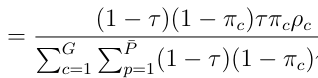

NOTE: contains mathematical notation; text above is the PDF text layer and symbols may be mis-extracted. Image shows the original.

**equation / math rendering (image)**

NOTE: contains mathematical notation; text above is the PDF text layer and symbols may be mis-extracted. Image shows the original.

NOTE: contains mathematical notation; text above is the PDF text layer and symbols may be mis-extracted. Image shows the original.

**equation / math rendering (image)**

NOTE: contains mathematical notation; text above is the PDF text layer and symbols may be mis-extracted. Image shows the original.

**equation / math rendering (image)**

NOTE: contains mathematical notation; text above is the PDF text layer and symbols may be mis-extracted. Image shows the original.

NOTE: contains mathematical notation; text above is the PDF text layer and symbols may be mis-extracted. Image shows the original.

**equation / math rendering (image)**

NOTE: contains mathematical notation; text above is the PDF text layer and symbols may be mis-extracted. Image shows the original.

### **Appendix B: Stata syntax**

Suppose that y refers to the outcome, year the year, id the group, and d treatment status.

The two-stage difference-in-differences estimator can be obtained, along with valid cluster-

robust asymptotic standard errors, via GMM using the single Stata command:

gmm (eq1: (y - {xb: i.year} - {xg: ibn.id})*(1-d)) ///

(eq2: y - {xb:} - {xg:} - {delta}*d), ///

instruments(eq1: i.year ibn.id) ///

instruments(eq2: d) winitial(identity) ///

onestep quickderivatives vce(cluster id)

Variations on the two-stage estimator (such as the the two-stage event-study estimator) can

be obtained using similar syntax.

23

Page 25

### **References**

Abadie, Alberto. 2005. “Semiparametric difference-in-differences estimators.” Review of Eco-

nomic Studies, 72(1): 1-19.

Angrist, Joshua D., and J¨orn-Steffen Pischke. 2009. Mostly Harmless Econometrics: An

Empiricist’s Companion. Princeton University Press.

Athey, Susan and Guido W. Imbens. 2018. “Design based analysis in difference-in-differences

settings with staggered adoption.” NBER working paper no. 24963.

Autor, David. 2003. “Outsourcing at will.” Journal of Labor Economics, 21(1): 1–42.

Borusyak, Kirill and Xavier Jaravel. 2017. “Revisiting event study designs, with an applica-

tion to the estimation of the marginal propensity to consume.” Working paper, Harvard

University.

Callaway, Brantly, and Pedro Sant’Anna. 2020. “Difference-in-differences with multiple time

periods and an application on the minimum wage and employment.” Journal of Econo-

metrics, forthcoming.

Cengiz, Doruk, Dube, Arindrajit, Lindner, Attila and Ben Zipperer. 2019. “The effect of

minimum wages on low-wage jobs.” Quarterly Journal of Economics, 134(4): 1405-1454.

de Chaisemartin, Cl´ement and Xavier D’Haultfœuille. 2020. “Two-way fixed effects estima-

tors with heterogeneous treatment effects.” American Economic Review, 110(9): 2964-

2996.

Deshpande, Manasi and Yue Li. 2019. “Who is screened out? Application costs and the

targeting of disability programs.” American Economic Journal: Economic Policy, 11(4):

213–248.

24

Page 26

Dumont, Michel, Rayp, Glenn, Thas, Oliver and Peter Willeme. 2005. “Correcting standard

errors in two-stage estimation procedures with generated regressands.” Oxford Bulletin of

Economics and Statistics, 67(3): 421-433.

Gibbons, Charles E., Su´arez Serrato, Juan Carlos, and Michael B. Urbancic. 2017. “Broken

or fixed effects.” Journal of Econometric Methods, 8(1): 2156-6674.

Goodman-Bacon, Andrew. 2018. “Difference-in-differences with variation in treatment tim-

ing.” NBER working paper no. 25018.

Gormley, Todd A. and David A. Matsa. “Growing out of trouble? Corporate responses to

liability risk.” Review of Financial Studies, 24(8):2781–2821.

Hansen, Lars P. (1982). “Large sample properties of generalized method of moments estima-

tors.” Econometrica, 50(4): 1029–1054.

Imai, Kosuke and In Song Kim. 2020. “On the use of two-way fixed effects regression models

for causal inference with panel data.” Political Analysis, forthcoming.

Newey, Whitney. 1984. “A method of moments interpretation of sequential estimators.”

Economics Letters, 14: 201–206.

Newey, Whitney K. and Daniel McFadden. 1994. “Large sample estimation and hypothesis

testing.” In R. F. Engle and D. L. McFadden (Eds.), Handbook of Econometrics, IV:

2112–2245. Elsevier Science.

Sun, Liyang and Sarah Abraham. 2020. “Estimating dynamic treatment effects in event

studies with heterogeneous treatment effects.” Journal of Econometrics, forthcoming.

Thakral, Neil and Linh Tˆo. 2020. “Anticipation and consumption.” Working paper.

25

Page 27

Table 1: Simulation results

|  |  | Simulation 1 | Simulation 2 |
| --- | --- | --- | --- |
| All periods | True | 4 08 . | 3 46 . |
|  | Diff -in-diff | 3 51 . (0 28) . | 2 72 . (0 23) . |
|  | A ggregated | 4 12 . (0 28) . | 3 48 . (0 22) . |
|  | Two-stage | 4 12 . (0 28) . | 3 48 . (0 22) . |
| Four-period | True | 3 17 . | 2 75 . |
|  | A ggregated | 3 21 . (0 32) . | 2 78 . (0 25) . |
|  | Stacked | 3 21 . (0 33) . | 2 87 . (0 26) . |
|  | Two-stage | 3 21 . (0 32) . | 2 78 . (0 25) . |

NOTE: table converted from PDF layout to HTML text; cell boundaries are reconstructed. See PDF if exact alignment matters.

Notes: Means and standard deviations from 250 simulations.

26

Page 28

Figure 1: Simulated DD weights

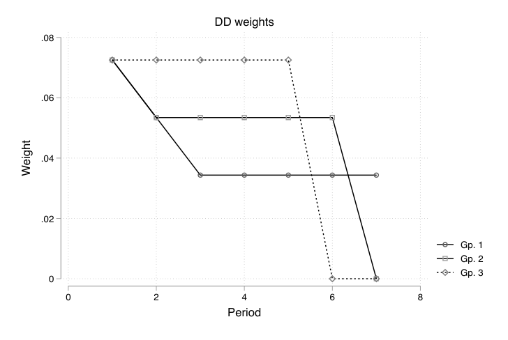

NOTE: figure/graphic rendered as an image from the PDF; its content is not machine-readable text. Caption (if any) follows as the next block.

**text found inside the figure**

0

.02

.04

.06

.08

Weight

0 2 4 6 8 Period

Gp. 1 Gp. 2

Gp. 3

DD weights

27

Page 29

Figure 2: Simulated event studies

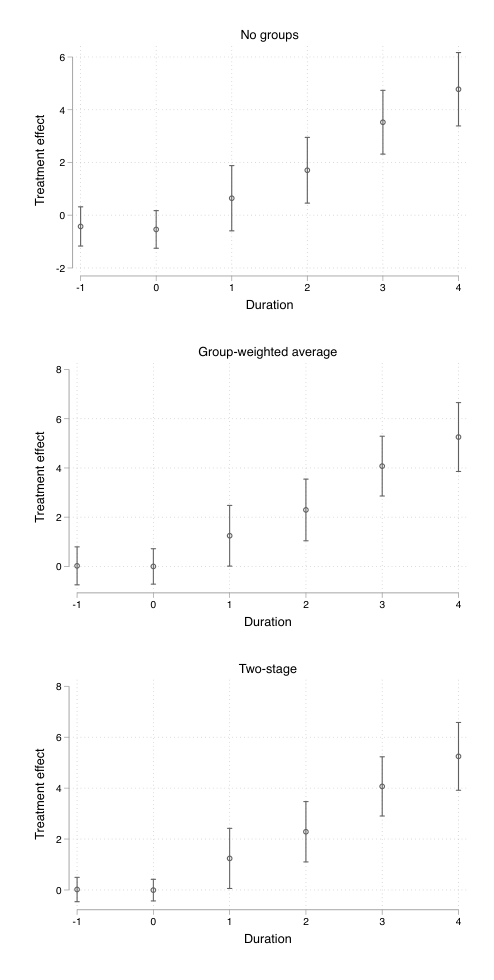

NOTE: figure/graphic rendered as an image from the PDF; its content is not machine-readable text. Caption (if any) follows as the next block.

**text found inside the figure**

-2

0

2

4

6

Treatment effect

-1 0 1 2 3 4 Duration

No groups

0

2

4

6

8

Treatment effect

-1 0 1 2 3 4 Duration

Group-weighted average

0

2

4

6

8

Treatment effect

-1 0 1 2 3 4 Duration

Two-stage

Notes: Means and *±* 2*×*standard deviations from 250 simulations.

28

Page 30

Figure 3: Application DD weights

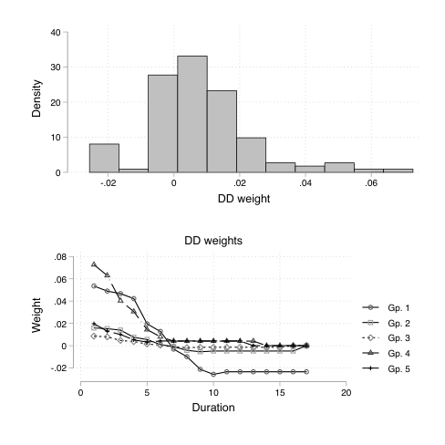

NOTE: figure/graphic rendered as an image from the PDF; its content is not machine-readable text. Caption (if any) follows as the next block.

**text found inside the figure**

0

10

20

30

40

Density

-.02 0 .02 .04 .06 DD weight

-.02

0

.02

.04

.06

.08

Weight

0 5 10 15 20 Duration

Gp. 1

Gp. 2

Gp. 3

Gp. 4

Gp. 5

DD weights

29

Page 31

Table 2: Application estimates

| All periods | Diff -in-diff | 0 112 . (0 096) . |
| --- | --- | --- |
|  | A ggregated | 0 087 . (0 158) . |
|  | Two-stage | 0 092 . (0 157) . |
|  | Two-stage (incl treat×time . in fi rst stage) | 0 097 . (0 149) . |
| Eight periods | A ggregated | 0 106 . (0 126) . |
|  | Stacked | 0 114 . (0 121) . |
|  | Two-stage | 0 110 . (0 126) . |

NOTE: table converted from PDF layout to HTML text; cell boundaries are reconstructed. See PDF if exact alignment matters.

Notes: Standard errors clustered on state. Standard errors for aggregated estimators calculated using the delta method, assuming that the treated distribution of groups and periods is fixed. Two-stage estimates computed by estimating both equations simultaneously by GMM.

30

Page 32

Figure 4: Application event studies

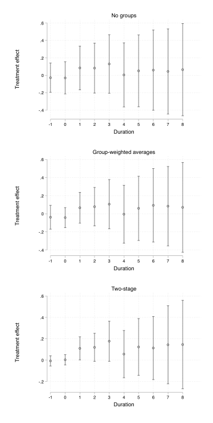

NOTE: figure/graphic rendered as an image from the PDF; its content is not machine-readable text. Caption (if any) follows as the next block.

**text found inside the figure**

-.4

-.2

0

.2

.4

.6

Treatment effect

-1 0 1 2 3 4 5 6 7 8 Duration

No groups

-.4

-.2

0

.2

.4

.6

Treatment effect

-1 0 1 2 3 4 5 6 7 8 Duration

Group-weighted averages

-.2

0

.2

.4

.6

Treatment effect

-1 0 1 2 3 4 5 6 7 8 Duration

Two-stage

Notes: Means and 95% confidence intervals (based on state-clustered standard errors).

31

Page 33

### **Appendix C: Event-study estimates**

Table 3: Simulation event-study results

|  | Simulation 1 |  | Simulation 2 |  |
| --- | --- | --- | --- | --- |
| Period | A ggregated No groups | Two-stage | A ggregated No groups | Two-stage |
| 1 - | 0 024 0 425 . - . (0 385) (0 372) . . | 0 018 . (0 239) . | 0 003 0 396 . - . (0 248) (0 236) . . | 0 007 . (0 147) . |
| 0 | 0 000 0 540 . - . (0 360) (0 357) . . | 0 006 - . (0 212) . | 0 003 0 607 - . - . (0 288) (0 286) . . | 0 004 - . (0 138) . |
| 1 | 1 246 0 645 . . (0 616) (0 619) . . | 1 239 . (0 590) . | 1 019 0 317 . . (0 464) (0 458) . . | 1 016 . (0 439) . |
| 2 | 2 295 1 706 . . (0 626) (0 623) . . | 2 286 . (0 592) . | 2 038 1 401 . . (0 460) (0 466) . . | 2 036 . (0 441) . |
| 3 | 4 075 3 526 . . (0 607) (0 605) . . | 4 068 . (0 581) . | 3 527 2 986 . . (0 460) (0 481) . . | 3 527 . (0 439) . |
| 4 | 5 255 4 777 . . (0 700) (0 695) . . | 5 249 . (0 666) . | 4 531 4 091 . . (0 478) (0 471) . . | 4 531 . (0 462) . |

NOTE: table converted from PDF layout to HTML text; cell boundaries are reconstructed. See PDF if exact alignment matters.

Notes: Means and standard deviations from 250 simulations.

32

Page 34

Table 4: Application event study estimates

[output not shown]

NOTE: table converted from PDF layout to HTML text; cell boundaries are reconstructed. See PDF if exact alignment matters.

Notes: Standard errors clustered on state. Standard errors for aggregated estimators calculated using the delta method, assuming that the treated distribution of groups and periods is fixed. Two-stage estimates computed by estimating both equations simultaneously by GMM.

33